# Soluzione esercizio 4

Cristiano Varin

Leggiamo i dati:

```r
diamanti <- read.csv("diamanti.csv")
```

Visualizziamo i dati:

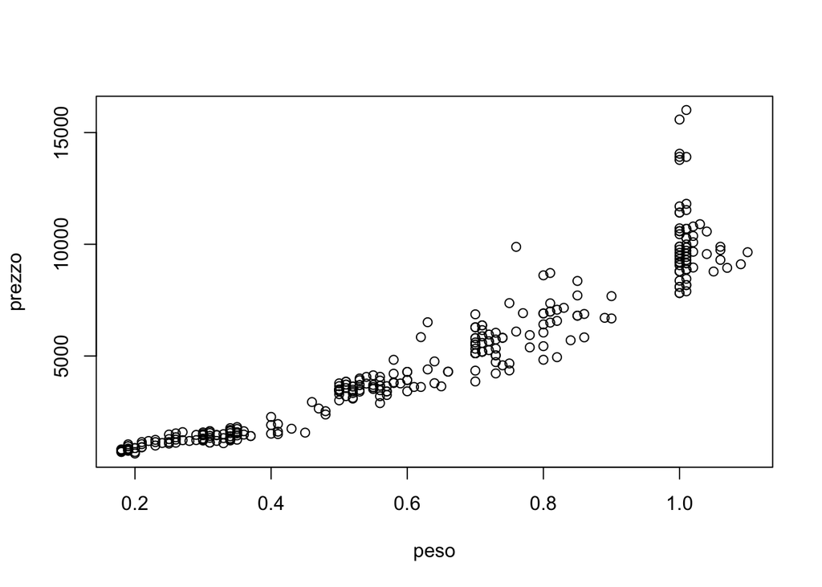

```r
plot(prezzo ~ peso, data = diamanti)
```

Il grafico mostra una relazione crescente non lineare fra prezzo e peso. Si nota anche un aumento della dispersione dei prezzi al crescere del peso.

Stimiamo la retta di regressione:

```r
mod <- lm(prezzo ~ peso, data = diamanti)
summary(mod)
```

```
##
## Call:
## lm(formula = prezzo ~ peso, data = diamanti)
##
## Residuals:
##     Min      1Q  Median      3Q     Max
## -2264.7  -604.3  -116.1   435.1  6591.5
##
## Coefficients:
##             Estimate Std. Error t value Pr(>|t|)
## (Intercept)  -2298.4      158.5  -14.50   <2e-16 ***
## peso         11598.9      230.1   50.41   <2e-16 ***
## ---
## Signif. codes:  0 '***' 0.001 '**' 0.01 '*' 0.05 '.' 0.1 ' ' 1
##
## Residual standard error: 1118 on 306 degrees of freedom
## Multiple R-squared:  0.8925, Adjusted R-squared:  0.8922
## F-statistic:  2541 on 1 and 306 DF,  p-value: < 2.2e-16
```

Analisi dei residui:

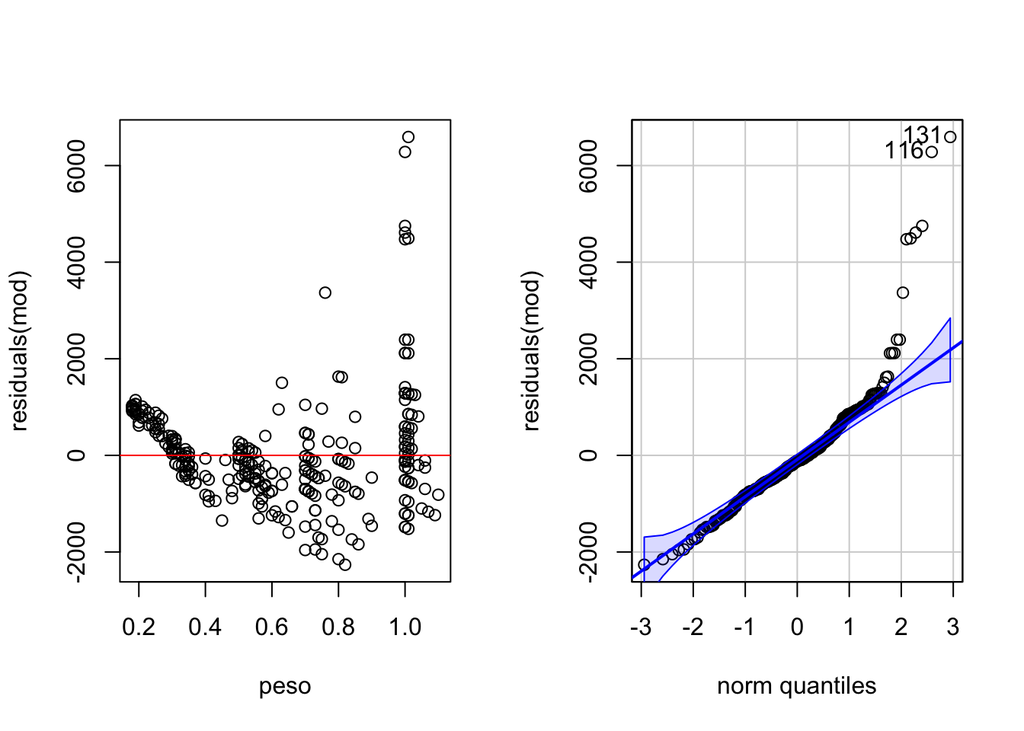

```
## [1] 131 116
```

```r
library(car)
par(mfrow = c(1, 2))
plot(residuals(mod) ~ peso, data = diamanti)
abline(h = 0, col = "red")
qqPlot(residuals(mod))
```

L’analisi dei residui indica che il modello non è adeguato.

Inoltre, il modello porta a stime del prezzo negative:

```r
summary(fitted(mod))
```

```
##    Min. 1st Qu.  Median    Mean 3rd Qu.    Max.
##  -210.6  1761.3  4892.9  5019.5  7560.7 10460.4
```

Per evitare previsioni negative, stimiamo il modello di regressione su scala logaritmica:

```r
mod <- lm(log(prezzo) ~ peso, data = diamanti)
summary(mod)
```

```
##
## Call:
## lm(formula = log(prezzo) ~ peso, data = diamanti)
##
## Residuals:
##      Min       1Q   Median       3Q      Max
## -0.55486 -0.16271 -0.00869  0.15522  0.59431
##
## Coefficients:
##             Estimate Std. Error t value Pr(>|t|)
## (Intercept)  6.44488    0.02938  219.40   <2e-16 ***
## peso         2.84155    0.04264   66.64   <2e-16 ***
## ---
## Signif. codes:  0 '***' 0.001 '**' 0.01 '*' 0.05 '.' 0.1 ' ' 1
##
## Residual standard error: 0.2071 on 306 degrees of freedom
## Multiple R-squared:  0.9355, Adjusted R-squared:  0.9353
## F-statistic:  4441 on 1 and 306 DF,  p-value: < 2.2e-16
```

Analisi dei residui:

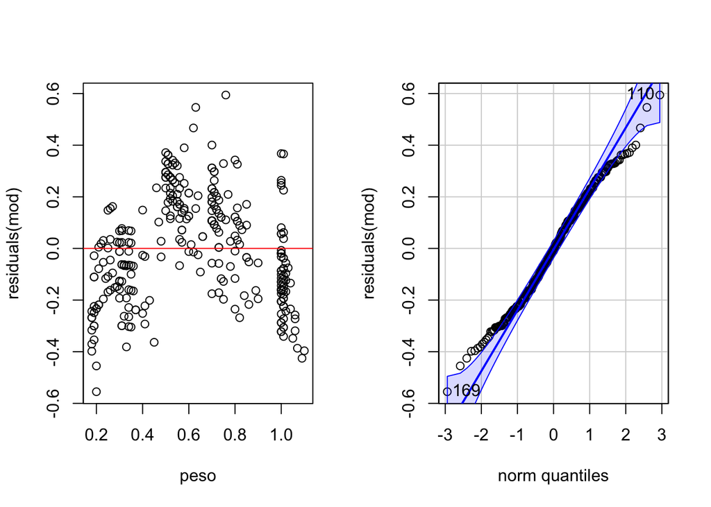

```
## [1] 110 169
```

```r
library(car)
par(mfrow = c(1, 2))
plot(residuals(mod) ~ peso, data = diamanti)
abline(h = 0, col = "red")
qqPlot(residuals(mod))
```

L’analisi dei residui indica che il modello non è adeguato e suggerisce una relazione non lineare fra il logaritmo del prezzo e il peso dei diamanti.

Aggiungiamo un effetto quadratico:

```r
mod2 <- update(mod, . ~ . + I(peso ^ 2))
summary(mod2)
```

```
##
## Call:
## lm(formula = log(prezzo) ~ peso + I(peso^2), data = diamanti)
##
## Residuals:
##      Min       1Q   Median       3Q      Max
## -0.45187 -0.08858 -0.00441  0.09685  0.50045
##
## Coefficients:
##             Estimate Std. Error t value Pr(>|t|)
## (Intercept)   5.7806     0.0483  119.68   <2e-16 ***
## peso          5.4368     0.1709   31.81   <2e-16 ***
## I(peso^2)    -2.0501     0.1326  -15.46   <2e-16 ***
## ---
## Signif. codes:  0 '***' 0.001 '**' 0.01 '*' 0.05 '.' 0.1 ' ' 1
##
## Residual standard error: 0.1553 on 305 degrees of freedom
## Multiple R-squared:  0.9639, Adjusted R-squared:  0.9636
## F-statistic:  4066 on 2 and 305 DF,  p-value: < 2.2e-16
```

Il modello quadratico ha un valore dell’indice $R^2$ aggiustato più alto del modello lineare. Proviamo il modello cubico:

```r
mod3 <- update(mod2, . ~ . + I(peso ^ 3))
summary(mod3)
```

```
##
## Call:
## lm(formula = log(prezzo) ~ peso + I(peso^2) + I(peso^3), data = diamanti)
##
## Residuals:
##      Min       1Q   Median       3Q      Max
## -0.45597 -0.09053 -0.00122  0.09584  0.49944
##
## Coefficients:
##             Estimate Std. Error t value Pr(>|t|)
## (Intercept)   5.7427     0.1171  49.039  < 2e-16 ***
## peso          5.6813     0.7094   8.008 2.49e-14 ***
## I(peso^2)    -2.4924     1.2523  -1.990   0.0475 *
## I(peso^3)     0.2359     0.6643   0.355   0.7227
## ---
## Signif. codes:  0 '***' 0.001 '**' 0.01 '*' 0.05 '.' 0.1 ' ' 1
##
## Residual standard error: 0.1556 on 304 degrees of freedom
## Multiple R-squared:  0.9639, Adjusted R-squared:  0.9635
## F-statistic:  2703 on 3 and 304 DF,  p-value: < 2.2e-16
```

Non vi è miglioramento nel passare al modello cubico.

L’analisi dei residui del modello quadratico:

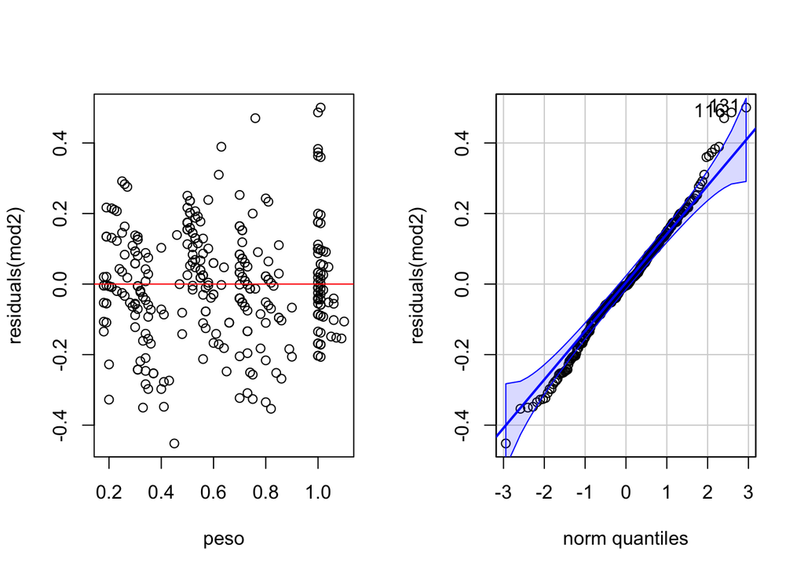

```
## [1] 131 116
```

```r
library(car)
par(mfrow = c(1, 2))
plot(residuals(mod2) ~ peso, data = diamanti)
abline(h = 0, col = "red")
qqPlot(residuals(mod2))
```

Il residui del modello quadratico sono decisamente migliorati rispetto al modello lineare anche se il grafico quantile-quantile non è del tutto soddisfacente sulle code.

Il modello quadratico spiega il 96% della variabilità del prezzo su scala logaritmica.

Visualizziamo il modello stimato:

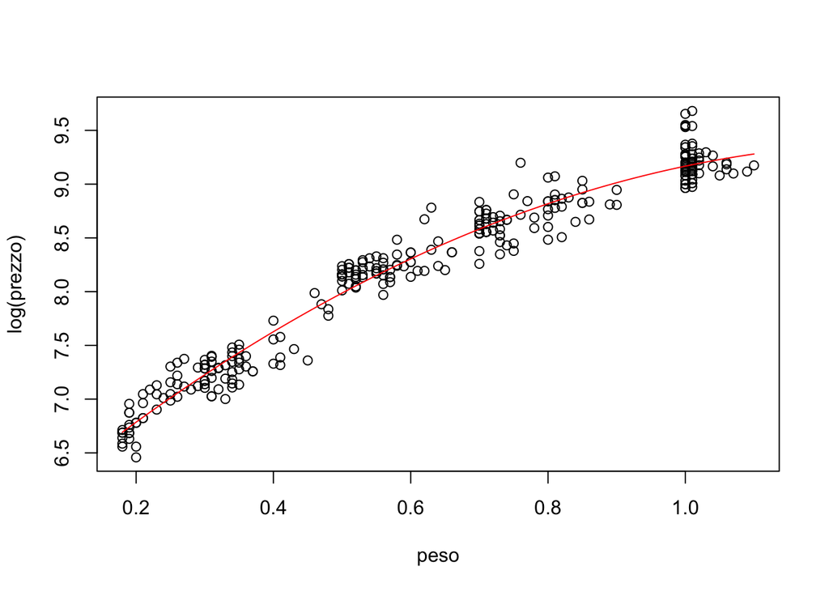

```r
plot(log(prezzo) ~ peso, data = diamanti)
curve(coef(mod2)[1] + coef(mod2)[2] * x + coef(mod2)[3] * x^2, from = min(diamanti$peso), to = max(diamanti$peso), add = TRUE, col = "red")
```

Calcoliamo l’intervallo di previsione al 99% per il prezzo di un diamante di 0.5 carati:

```r
pr <- predict(mod2, newdata = data.frame(peso = 0.5), interval = "prediction", level = 0.99)
exp(pr)
```

```
##        fit      lwr      upr
## 1 2940.795 1963.546 4404.418
```

Se la pietra pesasse 1 carato allora il prezzo previsto dal modello sarebbe:

```r
pr <- predict(mod2, newdata = data.frame(peso = 1), interval = "prediction", level = 0.99)
exp(pr)
```

```
##        fit      lwr      upr
## 1 9578.124 6388.853 14359.46
```